# Exploratory Data Analysis Report

Report by dlookr package

2022-10-10

# 1 Introduction

The EDA Report provides exploratory data analysis information on objects that inherit data.frame and data.frame.

## 1.1 Information of Dataset

The dataset that generated the EDA Report is an **‘data.frame’** object. It consists of **517 observations** and **13 variables**.

## 1.2 Information of Variables

The variable information of the data set that generated the EDA Report is shown in the following table.:

Information of Variables

| variables | types | missing_count | missing_percent | unique_count | unique_rate |
| --- | --- | --- | --- | --- | --- |
| X | integer | 0 | 0 | 9 | 0.017 |
| Y | integer | 0 | 0 | 7 | 0.014 |
| month | numeric | 0 | 0 | 12 | 0.023 |
| day | numeric | 0 | 0 | 7 | 0.014 |
| FFMC | numeric | 0 | 0 | 106 | 0.205 |
| DMC | numeric | 0 | 0 | 215 | 0.416 |
| DC | numeric | 0 | 0 | 219 | 0.424 |
| ISI | numeric | 0 | 0 | 119 | 0.230 |
| temp | numeric | 0 | 0 | 192 | 0.371 |
| RH | integer | 0 | 0 | 75 | 0.145 |
| wind | numeric | 0 | 0 | 21 | 0.041 |
| rain | numeric | 0 | 0 | 7 | 0.014 |
| area | numeric | 0 | 0 | 251 | 0.485 |

The target variable of the data is **‘area’**, and the data type of the variable is **numeric**.

## 1.3 About EDA Report

EDA reports provide information and visualization results that support the EDA process. In particular, it provides a variety of information to understand the relationship between the target variable and the rest of the variables of interest.

# 2 Univariate Analysis

## 2.1 Descriptive Statistics

edaData  
13 Variables 517 Observations

X

| n | missing | distinct | Info | Mean | Gmd |
| --- | --- | --- | --- | --- | --- |
| 517 | 0 | 9 | 0.982 | 4.669 | 2.648 |

lowest : 1 2 3 4 5 , highest: 5 6 7 8 9

```
 Value          1     2     3     4     5     6     7     8     9
 Frequency     48    73    55    91    30    86    60    61    13
 Proportion 0.093 0.141 0.106 0.176 0.058 0.166 0.116 0.118 0.025
```

Y

| n | missing | distinct | Info | Mean | Gmd |
| --- | --- | --- | --- | --- | --- |
| 517 | 0 | 7 | 0.92 | 4.3 | 1.309 |

lowest : 2 3 4 5 6 , highest: 4 5 6 8 9

```
 Value          2     3     4     5     6     8     9
 Frequency     44    64   203   125    74     1     6
 Proportion 0.085 0.124 0.393 0.242 0.143 0.002 0.012
```

month

| n | missing | distinct | Info | Mean | Gmd | .05 | .10 | .25 | .50 | .75 | .90 | .95 |
| --- | --- | --- | --- | --- | --- | --- | --- | --- | --- | --- | --- | --- |
| 517 | 0 | 12 | 0.917 | 7.476 | 2.244 | 3 | 3 | 7 | 8 | 9 | 9 | 9 |

lowest : 1 2 3 4 5 , highest: 8 9 10 11 12

```
 Value          1     2     3     4     5     6     7     8     9    10    11    12
 Frequency      2    20    54     9     2    17    32   184   172    15     1     9
 Proportion 0.004 0.039 0.104 0.017 0.004 0.033 0.062 0.356 0.333 0.029 0.002 0.017
```

day

| n | missing | distinct | Info | Mean | Gmd |
| --- | --- | --- | --- | --- | --- |
| 517 | 0 | 7 | 0.977 | 3.973 | 2.446 |

lowest : 1 2 3 4 5 , highest: 3 4 5 6 7

```
 Value          1     2     3     4     5     6     7
 Frequency     95    74    64    54    61    85    84
 Proportion 0.184 0.143 0.124 0.104 0.118 0.164 0.162
```

FFMC

| n | missing | distinct | Info | Mean | Gmd | .05 | .10 | .25 | .50 | .75 | .90 | .95 |
| --- | --- | --- | --- | --- | --- | --- | --- | --- | --- | --- | --- | --- |
| 517 | 0 | 106 | 0.999 | 90.64 | 4.053 | 84.1 | 85.9 | 90.2 | 91.6 | 92.9 | 94.3 | 95.1 |

lowest : 18.7 50.4 53.4 63.5 68.2 , highest: 95.8 95.9 96.0 96.1 96.2

DMC

| n | missing | distinct | Info | Mean | Gmd | .05 | .10 | .25 | .50 | .75 | .90 | .95 |
| --- | --- | --- | --- | --- | --- | --- | --- | --- | --- | --- | --- | --- |
| 517 | 0 | 215 | 1 | 110.9 | 71.27 | 14.92 | 25.70 | 68.60 | 108.30 | 142.40 | 195.18 | 231.10 |

lowest : 1.1 2.4 3.0 3.2 3.6 , highest: 276.3 284.9 287.2 290.0 291.3

DC

| n | missing | distinct | Info | Mean | Gmd | .05 | .10 | .25 | .50 | .75 | .90 | .95 |
| --- | --- | --- | --- | --- | --- | --- | --- | --- | --- | --- | --- | --- |
| 517 | 0 | 219 | 1 | 547.9 | 257.3 | 43.58 | 80.80 | 437.70 | 664.20 | 713.90 | 758.10 | 795.30 |

lowest : 7.9 9.3 15.3 15.5 15.8 , highest: 825.1 844.0 849.3 855.3 860.6

ISI

| n | missing | distinct | Info | Mean | Gmd | .05 | .10 | .25 | .50 | .75 | .90 | .95 |
| --- | --- | --- | --- | --- | --- | --- | --- | --- | --- | --- | --- | --- |
| 517 | 0 | 119 | 1 | 9.022 | 4.631 | 2.6 | 3.8 | 6.5 | 8.4 | 10.8 | 14.3 | 17.0 |

lowest : 0.0 0.4 0.7 0.8 1.1 , highest: 20.3 21.3 22.6 22.7 56.1

temp

| n | missing | distinct | Info | Mean | Gmd | .05 | .10 | .25 | .50 | .75 | .90 | .95 |
| --- | --- | --- | --- | --- | --- | --- | --- | --- | --- | --- | --- | --- |
| 517 | 0 | 192 | 1 | 18.89 | 6.494 | 8.20 | 11.20 | 15.50 | 19.30 | 22.80 | 25.98 | 27.90 |

lowest : 2.2 4.2 4.6 4.8 5.1 , highest: 32.3 32.4 32.6 33.1 33.3

RH

| n | missing | distinct | Info | Mean | Gmd | .05 | .10 | .25 | .50 | .75 | .90 | .95 |
| --- | --- | --- | --- | --- | --- | --- | --- | --- | --- | --- | --- | --- |
| 517 | 0 | 75 | 0.999 | 44.29 | 18.01 | 24 | 27 | 33 | 42 | 53 | 68 | 77 |

lowest : 15 17 18 19 20 , highest: 94 96 97 99 100

wind

| n | missing | distinct | Info | Mean | Gmd | .05 | .10 | .25 | .50 | .75 | .90 | .95 |
| --- | --- | --- | --- | --- | --- | --- | --- | --- | --- | --- | --- | --- |
| 517 | 0 | 21 | 0.994 | 4.018 | 2.007 | 1.3 | 1.8 | 2.7 | 4.0 | 4.9 | 6.3 | 7.6 |

lowest : 0.4 0.9 1.3 1.8 2.2 , highest: 7.6 8.0 8.5 8.9 9.4

rain

| n | missing | distinct | Info | Mean | Gmd |
| --- | --- | --- | --- | --- | --- |
| 517 | 0 | 7 | 0.046 | 0.02166 | 0.04312 |

lowest : 0.0 0.2 0.4 0.8 1.0 , highest: 0.4 0.8 1.0 1.4 6.4

```
 Value        0.0   0.2   0.4   0.8   1.0   1.4   6.4
 Frequency    509     2     1     2     1     1     1
 Proportion 0.985 0.004 0.002 0.004 0.002 0.002 0.002
```

area

| n | missing | distinct | Info | Mean | Gmd | .05 | .10 | .25 | .50 | .75 | .90 | .95 |
| --- | --- | --- | --- | --- | --- | --- | --- | --- | --- | --- | --- | --- |
| 517 | 0 | 251 | 0.891 | 12.85 | 22.7 | 0.00 | 0.00 | 0.00 | 0.52 | 6.57 | 25.26 | 48.71 |

lowest : 0.00 0.09 0.17 0.21 0.24 , highest: 200.94 212.88 278.53 746.28 1090.84

```
 Value          0    10    20    30    40    50    60    70    80    90   100   110
 Frequency    366    82    17    15     9     6     4     3     1     2     2     1
 Proportion 0.708 0.159 0.033 0.029 0.017 0.012 0.008 0.006 0.002 0.004 0.004 0.002

 Value        150   170   190   200   210   280   750  1090
 Frequency      1     1     1     2     1     1     1     1
 Proportion 0.002 0.002 0.002 0.004 0.002 0.002 0.002 0.002
```

For the frequency table, variable is rounded to the nearest 10

## 2.2 Normality Test of Numerical Variables

### 2.2.1 Statistics and Visualization of (Sample) Data

**[ X ]**

normality test : Shapiro-Wilk normality test

```
 statistic : 0.93757,  p-value : 6.70666E-14
```

skewness and kurtosis

| type | skewness | kurtosis |
| --- | --- | --- |
| original | 0.0361406 | 1.827393 |
| log transformation | -0.8090399 | 2.710078 |
| sqrt transformation | -0.3466383 | 2.034077 |

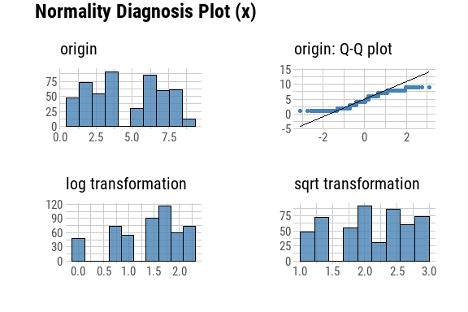

**[ Y ]**

normality test : Shapiro-Wilk normality test

```
 statistic : 0.90473,  p-value : 1.88539E-17
```

skewness and kurtosis

| type | skewness | kurtosis |
| --- | --- | --- |
| original | 0.4160845 | 4.395269 |
| log transformation | -0.6965175 | 3.613671 |
| sqrt transformation | -0.1751853 | 3.557488 |

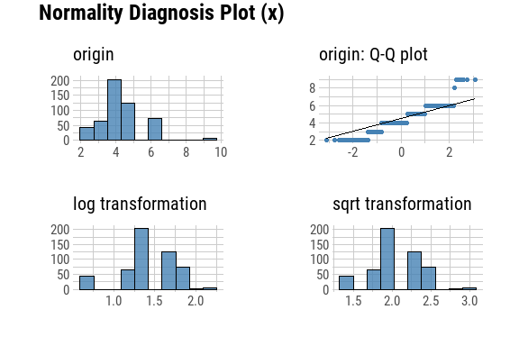

**[ month ]**

normality test : Shapiro-Wilk normality test

```
 statistic : 0.78142,  p-value : 1.01549E-25
```

skewness and kurtosis

| type | skewness | kurtosis |
| --- | --- | --- |
| original | -1.214476 | 3.626564 |
| log transformation | -1.832693 | 5.457078 |
| sqrt transformation | -1.514469 | 4.216981 |

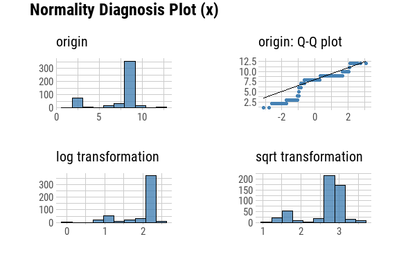

**[ day ]**

normality test : Shapiro-Wilk normality test

```
 statistic : 0.89295,  p-value : 1.65452E-18
```

skewness and kurtosis

| type | skewness | kurtosis |
| --- | --- | --- |
| original | -0.0038043 | 1.576895 |
| log transformation | -0.6089876 | 1.996752 |
| sqrt transformation | -0.2906493 | 1.696923 |

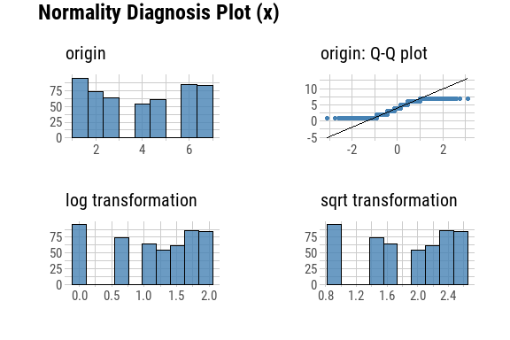

**[ FFMC ]**

normality test : Shapiro-Wilk normality test

```
 statistic : 0.53137,  p-value : 7.89069E-35
```

skewness and kurtosis

| type | skewness | kurtosis |
| --- | --- | --- |
| original | -6.556512 | 69.4076 |
| log transformation | -11.783082 | 190.4524 |
| sqrt transformation | -8.736021 | 115.2241 |

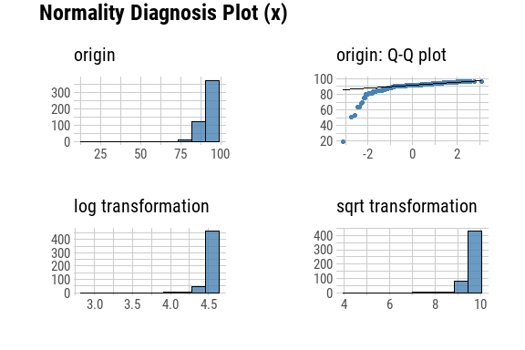

**[ DMC ]**

normality test : Shapiro-Wilk normality test

```
 statistic : 0.96381,  p-value : 5.65379E-10
```

skewness and kurtosis

| type | skewness | kurtosis |
| --- | --- | --- |
| original | 0.5459080 | 3.191263 |
| log transformation | -1.6881823 | 6.439994 |
| sqrt transformation | -0.3788577 | 2.928044 |

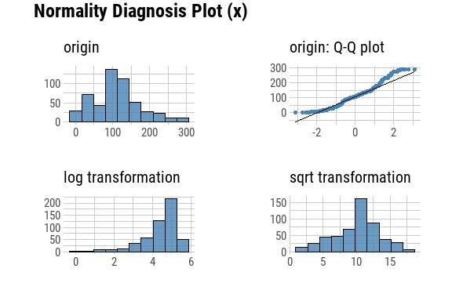

**[ DC ]**

normality test : Shapiro-Wilk normality test

```
 statistic : 0.80134,  p-value : 1.1112E-24
```

skewness and kurtosis

| type | skewness | kurtosis |
| --- | --- | --- |
| original | -1.097250 | 2.745539 |
| log transformation | -1.880462 | 5.478686 |
| sqrt transformation | -1.405342 | 3.491488 |

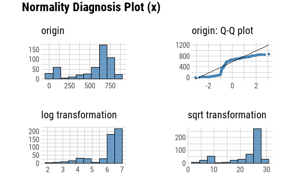

**[ ISI ]**

normality test : Shapiro-Wilk normality test

```
 statistic : 0.86446,  p-value : 9.43266E-21
```

skewness and kurtosis

| type | skewness | kurtosis |
| --- | --- | --- |
| original | 2.5289606 | 24.239490 |
| log+1 transformation | -0.9344964 | 5.548076 |
| sqrt transformation | 0.1476072 | 6.176865 |

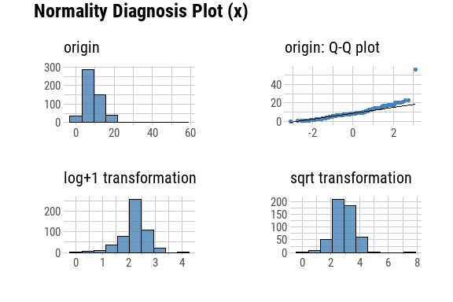

**[ temp ]**

normality test : Shapiro-Wilk normality test

```
 statistic : 0.9868,  p-value : 0.000125576
```

skewness and kurtosis

| type | skewness | kurtosis |
| --- | --- | --- |
| original | -0.3302106 | 3.123269 |
| log transformation | -1.6914903 | 6.802505 |
| sqrt transformation | -0.9322196 | 4.153572 |

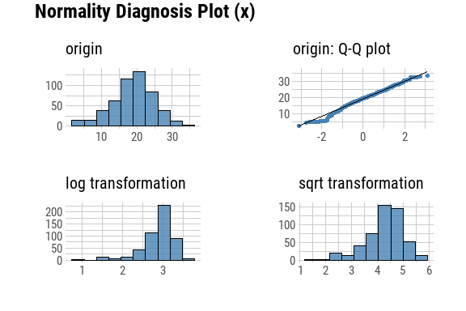

**[ RH ]**

normality test : Shapiro-Wilk normality test

```
 statistic : 0.94564,  p-value : 7.79723E-13
```

skewness and kurtosis

| type | skewness | kurtosis |
| --- | --- | --- |
| original | 0.8603984 | 3.422374 |
| log transformation | 0.0278622 | 2.589961 |
| sqrt transformation | 0.4487260 | 2.766406 |

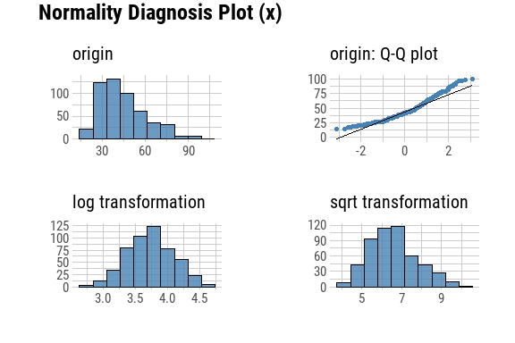

**[ wind ]**

normality test : Shapiro-Wilk normality test

```
 statistic : 0.96727,  p-value : 2.49494E-09
```

skewness and kurtosis

| type | skewness | kurtosis |
| --- | --- | --- |
| original | 0.5693431 | 3.042217 |
| log transformation | -0.7126038 | 3.698131 |
| sqrt transformation | -0.0082345 | 2.694528 |

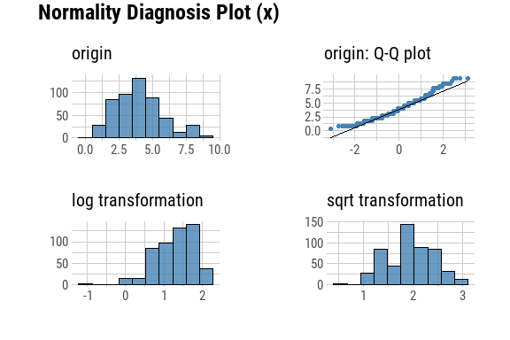

**[ rain ]**

normality test : Shapiro-Wilk normality test

```
 statistic : 0.04647,  p-value : 1.27061E-44
```

skewness and kurtosis

| type | skewness | kurtosis |
| --- | --- | --- |
| original | 19.75880 | 420.2210 |
| log+1 transformation | 14.13187 | 234.9692 |
| sqrt transformation | 12.45658 | 186.1667 |

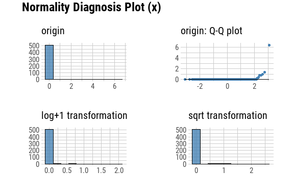

# 3 Relationship Between Variables

## 3.1 Correlation Coefficient

### 3.1.1 Correlation Coefficient by Variable Combination

Table of correlation coefficients (0.5 or more)

| Variable1 | Variable2 | Correlation Coefficient |
| --- | --- | --- |
| DC | month | 0.8686978 |
| DC | DMC | 0.6821916 |
| Y | X | 0.5395482 |
| ISI | FFMC | 0.5318049 |
| RH | temp | -0.5273903 |

### 3.1.2 Correlation Plot of Numerical Variables

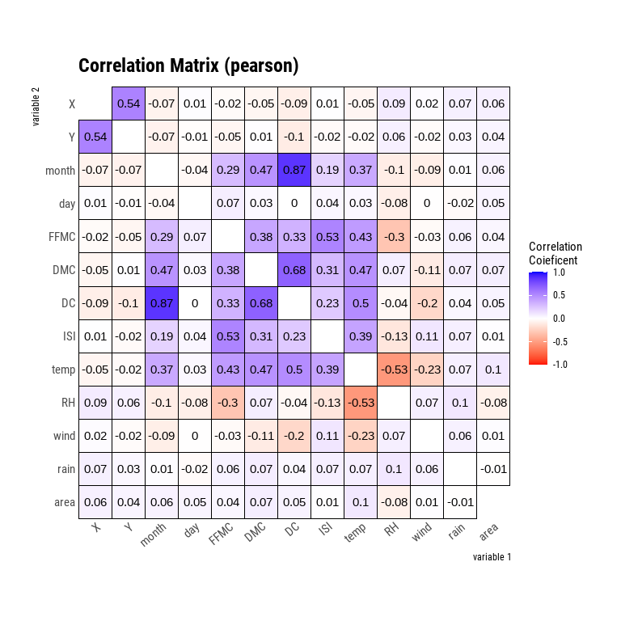

# 4 Target based Analysis

## 4.1 Grouped Descriptive Statistics

### 4.1.1 Grouped Numerical Variables

**[ X ]**

Simple Linear Model Information

```
 Residual standard error: 64 on 515 degrees of freedom
 Multiple R-squared:  0.00402,  Adjusted R-squared:  0.00208
 F-statistic: 2 on 1 and 515 DF,  p-value: 0.150096488623452
```

Coefficients:

Simple Linear Model coefficients : X

|  | Estimate | Std. Error | t value | Pr(>\|t\|) |
| --- | --- | --- | --- | --- |
| (Intercept) | 4.70 | 6.30 | 0.75 | 0.46 |
| X | 1.74 | 1.21 | 1.44 | 0.15 |

Visualization:

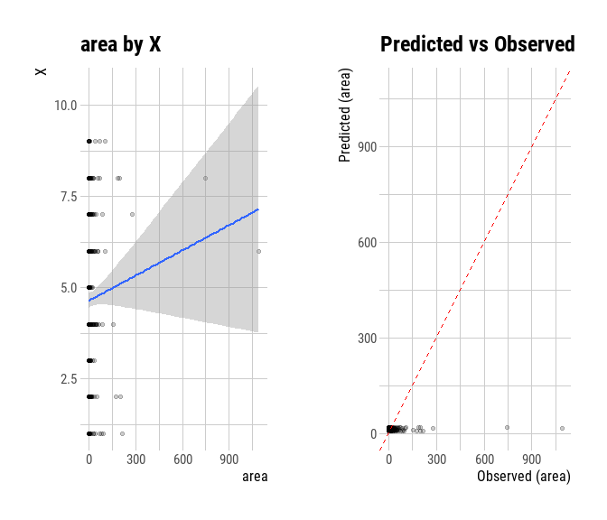

**[ Y ]**

Simple Linear Model Information

```
 Residual standard error: 64 on 515 degrees of freedom
 Multiple R-squared:  0.00201,  Adjusted R-squared:  8e-05
 F-statistic: 1 on 1 and 515 DF,  p-value: 0.308509591462425
```

Coefficients:

Simple Linear Model coefficients : Y

|  | Estimate | Std. Error | t value | Pr(>\|t\|) |
| --- | --- | --- | --- | --- |
| (Intercept) | 2.86 | 10.19 | 0.28 | 0.78 |
| Y | 2.32 | 2.28 | 1.02 | 0.31 |

Visualization:

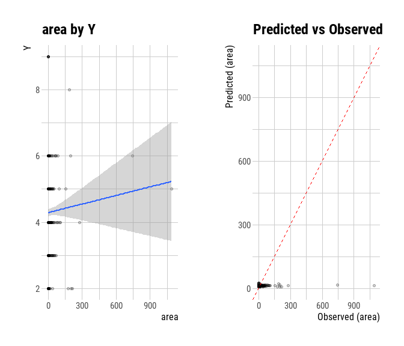

**[ month ]**

Simple Linear Model Information

```
 Residual standard error: 64 on 515 degrees of freedom
 Multiple R-squared:  0.00319,  Adjusted R-squared:  0.00126
 F-statistic: 2 on 1 and 515 DF,  p-value: 0.199668916098046
```

Coefficients:

Simple Linear Model coefficients : month

|  | Estimate | Std. Error | t value | Pr(>\|t\|) |
| --- | --- | --- | --- | --- |
| (Intercept) | 1.03 | 9.61 | 0.11 | 0.91 |
| month | 1.58 | 1.23 | 1.28 | 0.20 |

Visualization:

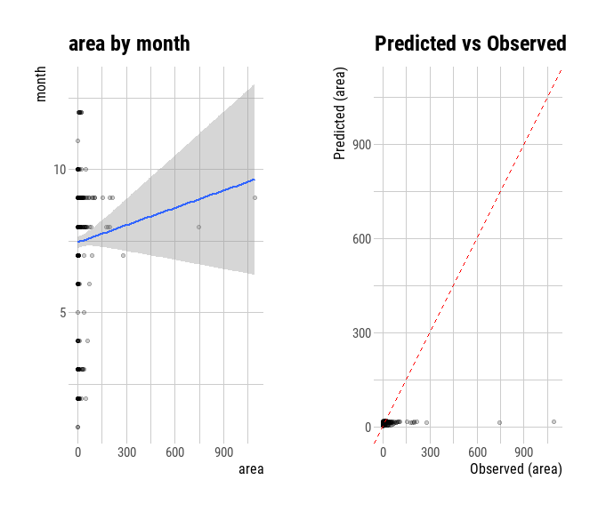

**[ day ]**

Simple Linear Model Information

```
 Residual standard error: 64 on 515 degrees of freedom
 Multiple R-squared:  0.00234,  Adjusted R-squared:  4e-04
 F-statistic: 1 on 1 and 515 DF,  p-value: 0.272397794104685
```

Coefficients:

Simple Linear Model coefficients : day

|  | Estimate | Std. Error | t value | Pr(>\|t\|) |
| --- | --- | --- | --- | --- |
| (Intercept) | 7.14 | 5.90 | 1.21 | 0.23 |
| day | 1.44 | 1.31 | 1.10 | 0.27 |

Visualization:

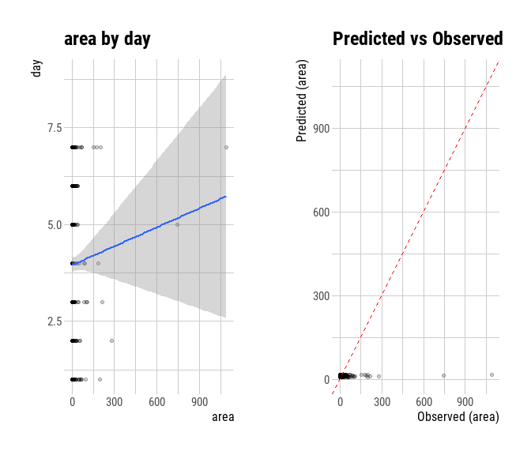

**[ FFMC ]**

Simple Linear Model Information

```
 Residual standard error: 64 on 515 degrees of freedom
 Multiple R-squared:  0.00161,  Adjusted R-squared:  -0.00033
 F-statistic: 1 on 1 and 515 DF,  p-value: 0.362591609953324
```

Coefficients:

Simple Linear Model coefficients : FFMC

|  | Estimate | Std. Error | t value | Pr(>\|t\|) |
| --- | --- | --- | --- | --- |
| (Intercept) | -29.09 | 46.11 | -0.63 | 0.53 |
| FFMC | 0.46 | 0.51 | 0.91 | 0.36 |

Visualization:

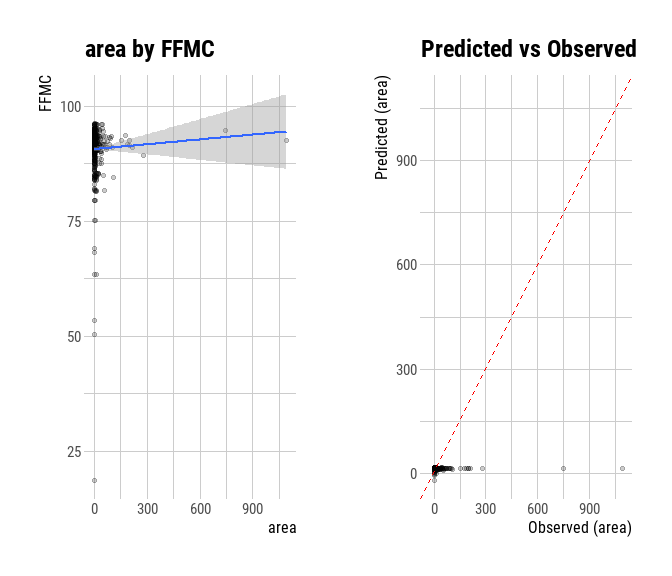

**[ DMC ]**

Simple Linear Model Information

```
 Residual standard error: 64 on 515 degrees of freedom
 Multiple R-squared:  0.00533,  Adjusted R-squared:  0.0034
 F-statistic: 3 on 1 and 515 DF,  p-value: 0.0973351343657216
```

Coefficients:

Simple Linear Model coefficients : DMC

|  | Estimate | Std. Error | t value | Pr(>\|t\|) |
| --- | --- | --- | --- | --- |
| (Intercept) | 4.80 | 5.59 | 0.86 | 0.39 |
| DMC | 0.07 | 0.04 | 1.66 | 0.10 |

Visualization:

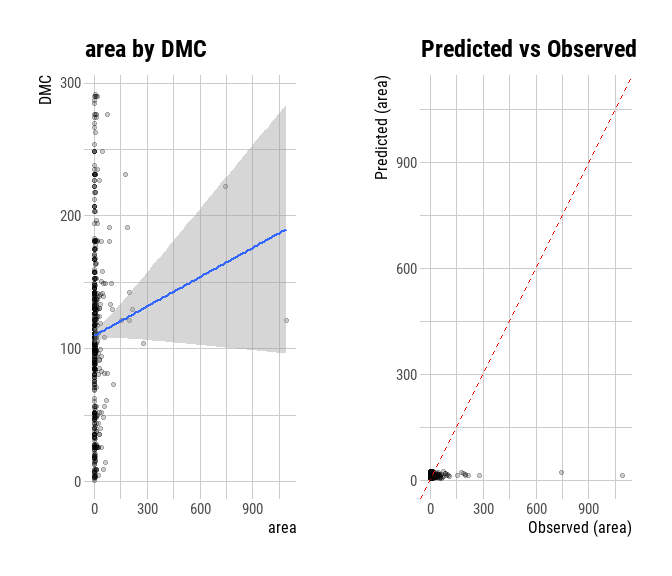

**[ DC ]**

Simple Linear Model Information

```
 Residual standard error: 64 on 515 degrees of freedom
 Multiple R-squared:  0.00244,  Adjusted R-squared:  5e-04
 F-statistic: 1 on 1 and 515 DF,  p-value: 0.262362882363784
```

Coefficients:

Simple Linear Model coefficients : DC

|  | Estimate | Std. Error | t value | Pr(>\|t\|) |
| --- | --- | --- | --- | --- |
| (Intercept) | 5.90 | 6.79 | 0.87 | 0.39 |
| DC | 0.01 | 0.01 | 1.12 | 0.26 |

Visualization:

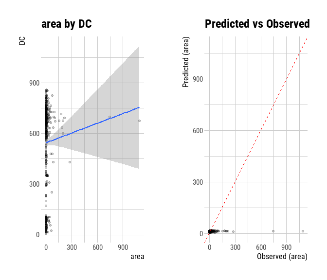

**[ ISI ]**

Simple Linear Model Information

```
 Residual standard error: 64 on 515 degrees of freedom
 Multiple R-squared:  7e-05,    Adjusted R-squared:  -0.00187
 F-statistic: 0 on 1 and 515 DF,  p-value: 0.851418362373284
```

Coefficients:

Simple Linear Model coefficients : ISI

|  | Estimate | Std. Error | t value | Pr(>\|t\|) |
| --- | --- | --- | --- | --- |
| (Intercept) | 11.81 | 6.22 | 1.90 | 0.06 |
| ISI | 0.12 | 0.62 | 0.19 | 0.85 |

Visualization:

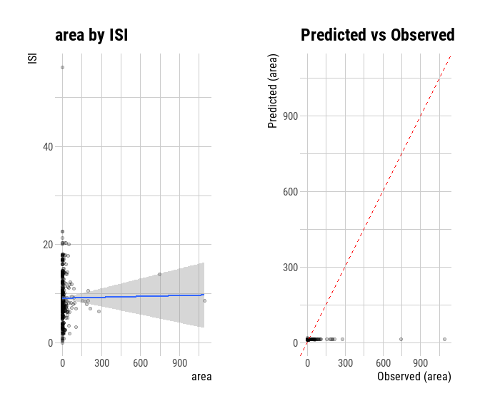

**[ temp ]**

Simple Linear Model Information

```
 Residual standard error: 63 on 515 degrees of freedom
 Multiple R-squared:  0.00957,  Adjusted R-squared:  0.00765
 F-statistic: 5 on 1 and 515 DF,  p-value: 0.0261014605798861
```

Coefficients:

Simple Linear Model coefficients : temp

|  | Estimate | Std. Error | t value | Pr(>\|t\|) |
| --- | --- | --- | --- | --- |
| (Intercept) | -7.41 | 9.50 | -0.78 | 0.44 |
| temp | 1.07 | 0.48 | 2.23 | 0.03 |

Visualization:

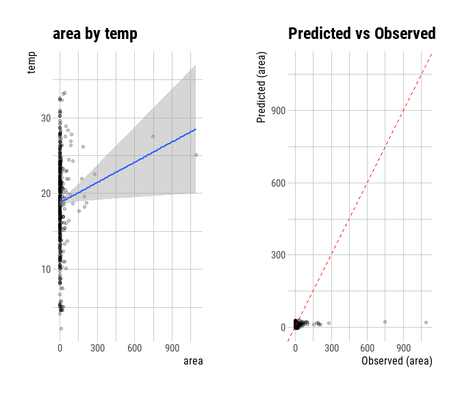

**[ RH ]**

Simple Linear Model Information

```
 Residual standard error: 64 on 515 degrees of freedom
 Multiple R-squared:  0.0057,   Adjusted R-squared:  0.00377
 F-statistic: 3 on 1 and 515 DF,  p-value: 0.0862705515385744
```

Coefficients:

Simple Linear Model coefficients : RH

|  | Estimate | Std. Error | t value | Pr(>\|t\|) |
| --- | --- | --- | --- | --- |
| (Intercept) | 25.89 | 8.09 | 3.20 | 0.00 |
| RH | -0.29 | 0.17 | -1.72 | 0.09 |

Visualization:

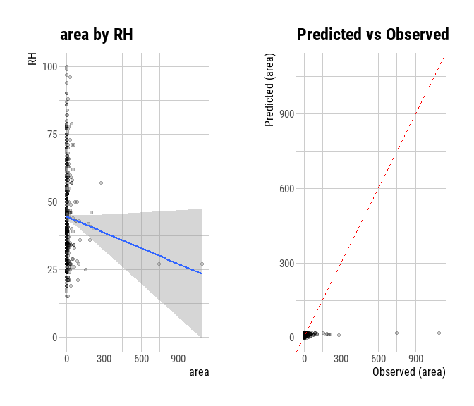

**[ wind ]**

Simple Linear Model Information

```
 Residual standard error: 64 on 515 degrees of freedom
 Multiple R-squared:  0.00015,  Adjusted R-squared:  -0.00179
 F-statistic: 0 on 1 and 515 DF,  p-value: 0.779939070361522
```

Coefficients:

Simple Linear Model coefficients : wind

|  | Estimate | Std. Error | t value | Pr(>\|t\|) |
| --- | --- | --- | --- | --- |
| (Intercept) | 11.09 | 6.89 | 1.61 | 0.11 |
| wind | 0.44 | 1.57 | 0.28 | 0.78 |

Visualization:

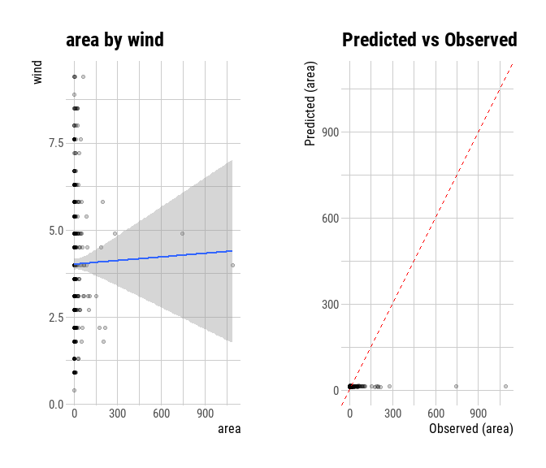

**[ rain ]**

Simple Linear Model Information

```
 Residual standard error: 64 on 515 degrees of freedom
 Multiple R-squared:  5e-05,    Adjusted R-squared:  -0.00189
 F-statistic: 0 on 1 and 515 DF,  p-value: 0.867310138627012
```

Coefficients:

Simple Linear Model coefficients : rain

|  | Estimate | Std. Error | t value | Pr(>\|t\|) |
| --- | --- | --- | --- | --- |
| (Intercept) | 12.88 | 2.81 | 4.58 | 0.00 |
| rain | -1.58 | 9.48 | -0.17 | 0.87 |

Visualization:

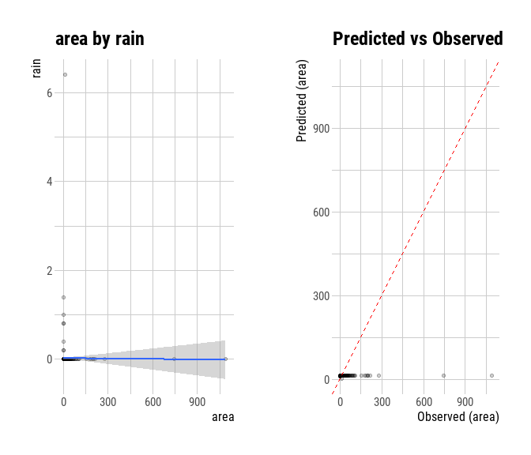

### 4.1.2 Grouped Categorical Variables

There is no categorical variable.

## 4.2 Grouped Relationship Between Variables

### 4.2.1 Grouped Correlation Coefficient

```
Numerical target variables are not supported.
```

### 4.2.2 Grouped Correlation Plot of Numerical Variables

```
Numerical target variables are not supported.
```